# Analise_Bank

Análise realizada utilizando as informações que estão no dataset https://archive.ics.uci.edu/ml/datasets/bank+marketing

Bibliotecas Necessárias

```r
# Importando
library(dplyr)
library(ggplot2)
library(caret)
```

Importando os dados

```r
# Importando os dados
dados <- read.csv("bank-full.csv", sep=";")
```

## Explorando os dados

Top 6 observações

```r
# Visualizando as 6 primeiras observações
head(dados)
```

```
##   age          job marital education default balance housing loan contact
## 1  58   management married  tertiary      no    2143     yes   no unknown
## 2  44   technician  single secondary      no      29     yes   no unknown
## 3  33 entrepreneur married secondary      no       2     yes  yes unknown
## 4  47  blue-collar married   unknown      no    1506     yes   no unknown
## 5  33      unknown  single   unknown      no       1      no   no unknown
## 6  35   management married  tertiary      no     231     yes   no unknown
##   day month duration campaign pdays previous poutcome  y
## 1   5   may      261        1    -1        0  unknown no
## 2   5   may      151        1    -1        0  unknown no
## 3   5   may       76        1    -1        0  unknown no
## 4   5   may       92        1    -1        0  unknown no
## 5   5   may      198        1    -1        0  unknown no
## 6   5   may      139        1    -1        0  unknown no
```

Nomes das colunas

```r
colnames(dados)
```

```
##  [1] "age"       "job"       "marital"   "education" "default"
##  [6] "balance"   "housing"   "loan"      "contact"   "day"
## [11] "month"     "duration"  "campaign"  "pdays"     "previous"
## [16] "poutcome"  "y"
```

Verificando se todas as linhas estão completas, ou seja, sem NULL

```r
sum(!complete.cases(dados))
```

```
## [1] 0
```

Visão geral dos dados

```r
summary(dados)
```

```
##       age                 job           marital          education
##  Min.   :18.00   blue-collar:9732   divorced: 5207   primary  : 6851
##  1st Qu.:33.00   management :9458   married :27214   secondary:23202
##  Median :39.00   technician :7597   single  :12790   tertiary :13301
##  Mean   :40.94   admin.     :5171                    unknown  : 1857
##  3rd Qu.:48.00   services   :4154
##  Max.   :95.00   retired    :2264
##                  (Other)    :6835
##  default        balance       housing      loan            contact
##  no :44396   Min.   : -8019   no :20081   no :37967   cellular :29285
##  yes:  815   1st Qu.:    72   yes:25130   yes: 7244   telephone: 2906
##              Median :   448                           unknown  :13020
##              Mean   :  1362
##              3rd Qu.:  1428
##              Max.   :102127
##
##       day            month          duration         campaign
##  Min.   : 1.00   may    :13766   Min.   :   0.0   Min.   : 1.000
##  1st Qu.: 8.00   jul    : 6895   1st Qu.: 103.0   1st Qu.: 1.000
##  Median :16.00   aug    : 6247   Median : 180.0   Median : 2.000
##  Mean   :15.81   jun    : 5341   Mean   : 258.2   Mean   : 2.764
##  3rd Qu.:21.00   nov    : 3970   3rd Qu.: 319.0   3rd Qu.: 3.000
##  Max.   :31.00   apr    : 2932   Max.   :4918.0   Max.   :63.000
##                  (Other): 6060
##      pdays          previous           poutcome       y
##  Min.   : -1.0   Min.   :  0.0000   failure: 4901   no :39922
##  1st Qu.: -1.0   1st Qu.:  0.0000   other  : 1840   yes: 5289
##  Median : -1.0   Median :  0.0000   success: 1511
##  Mean   : 40.2   Mean   :  0.5803   unknown:36959
##  3rd Qu.: -1.0   3rd Qu.:  0.0000
##  Max.   :871.0   Max.   :275.0000
##
```

## Gerando Insights

##### Insight 1

Na base de dados é possível obter a informação da profissão do correntista. Como que esses dados estão distribuidos? Qual a profissão mais recorrente?

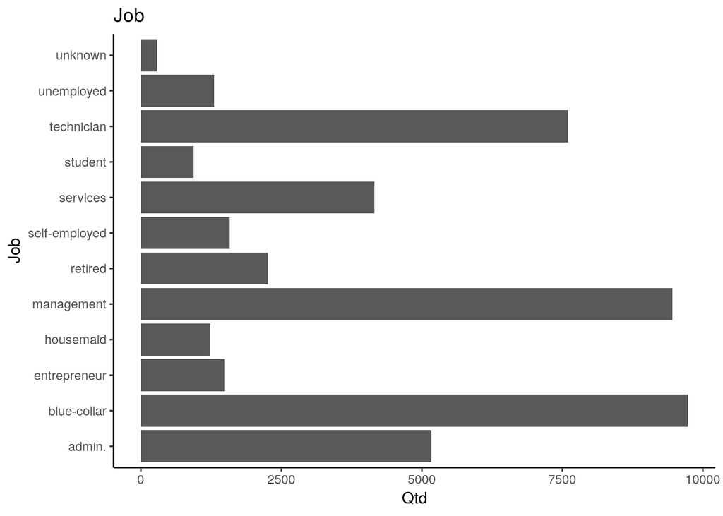

```r
to_Plot <- as.data.frame(table(dados$job))
colnames(to_Plot) <- c("Job", "Qtd")

ggplot(to_Plot, aes(x = Job, y = Qtd)) +
  geom_bar(stat = "identity") +
  labs(title = "Job") +
  theme_classic() +
  coord_flip()
```

A profissão que mais aparece nesse Bank é blue-collar, seguida por management e techinician.

##### Insight 2

Será que a blue-collar é a profissão que mais recebe emprestimos do banco?

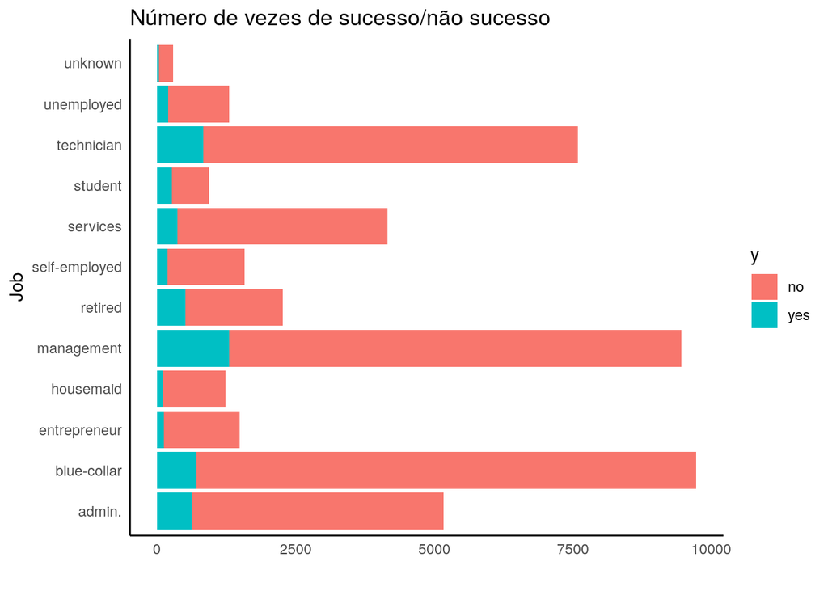

```r
dados_job <- dados %>%
            group_by(job, y) %>%
            summarise(qtd = n())


ggplot(data=dados_job,
      aes(x=reorder(job, job), y=qtd, fill=y)) +
 geom_bar(stat="identity") +
 labs(y='', x='Job', title = "Número de vezes de sucesso/não sucesso") +
 theme_classic() +
 theme(axis.ticks = element_blank())  +
  coord_flip()
```

Quando olhamos para números absolutos a profissão que mais recebe emprestimos é a management.

##### Insight 3

Será que esse rank se mantém se a gente levar em conta a quantidade de correntistas pela quantidade de emprestimos oferecidos?

```r
dados_true <- dados %>% filter(y == 'yes')
dados_false <- dados %>% filter(y == 'no')


group_true <- dados_true %>% group_by(job) %>% summarise(qtd = n())
group_false <- dados_false %>% group_by(job) %>% summarise(qtd_false = n())


join_dados <- left_join(group_true, group_false, by = "job")


join_dados$prop <- 100.0*join_dados$qtd/(join_dados$qtd+join_dados$qtd_false)

# Job com mais emprestimos
job_emprestimo <- tail(join_dados[order(join_dados$prop),], 1)$job

join_dados[order(-join_dados$prop),]
```

```
## # A tibble: 12 x 4
##    job             qtd qtd_false  prop
##    <fct>         <int>     <int> <dbl>
##  1 student         269       669 28.7
##  2 retired         516      1748 22.8
##  3 unemployed      202      1101 15.5
##  4 management     1301      8157 13.8
##  5 admin.          631      4540 12.2
##  6 self-employed   187      1392 11.8
##  7 unknown          34       254 11.8
##  8 technician      840      6757 11.1
##  9 services        369      3785  8.88
## 10 housemaid       109      1131  8.79
## 11 entrepreneur    123      1364  8.27
## 12 blue-collar     708      9024  7.27
```

Proporcionalmente a profissão student é a que mais tem tendência de realizar um emprestimo.

##### Insight 4

Agora que já sabemos qual a profissão que mais realiza emprestimo podemos olhar mais no detalhe e descobrir qual é a forma de contato preferida desse subgrupo

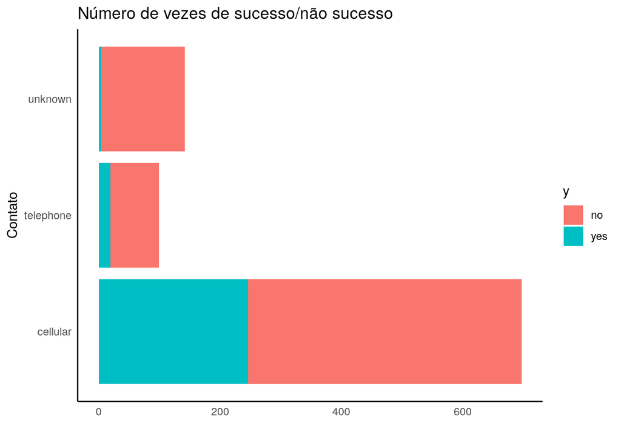

```r
# Job com mais emprestimos
dados_job <- dados %>% filter(job == 'student')


group_emprestimo <- dados_job %>%
            group_by(contact, y) %>%
            summarise(qtd = n())


ggplot(data=group_emprestimo,
      aes(x=reorder(contact, contact), y=qtd, fill=y)) +
 geom_bar(stat="identity") +
 labs(y='', x='Contato', title = "Número de vezes de sucesso/não sucesso") +
 theme_classic() +
 theme(axis.ticks = element_blank())  +
  coord_flip()
```

A grande maioria dos student foi contactado pelo celular

##### Insight 5

Muitas vezes os correntistas são abordados diversas vezes até realizar um emprestimo, quando observamos o número de contatos temos a seguinte distribuição

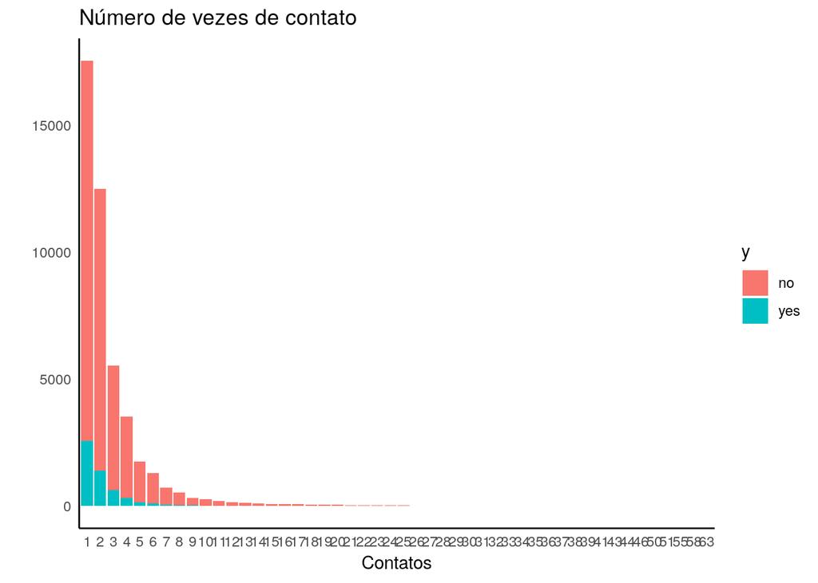

```r
group_campaign <- dados %>%
            group_by(campaign, y) %>%
            summarise(qtd = n())


ggplot(data=group_campaign,
      aes(x=reorder(campaign, campaign), y=qtd, fill=y)) +
 geom_bar(stat="identity") +
 labs(y='', x='Contatos', title = "Número de vezes de contato") +
 theme_classic() +
 theme(axis.ticks = element_blank())
```

##### Insight 6

Será que ligar apenas uma vez é o suficiente?

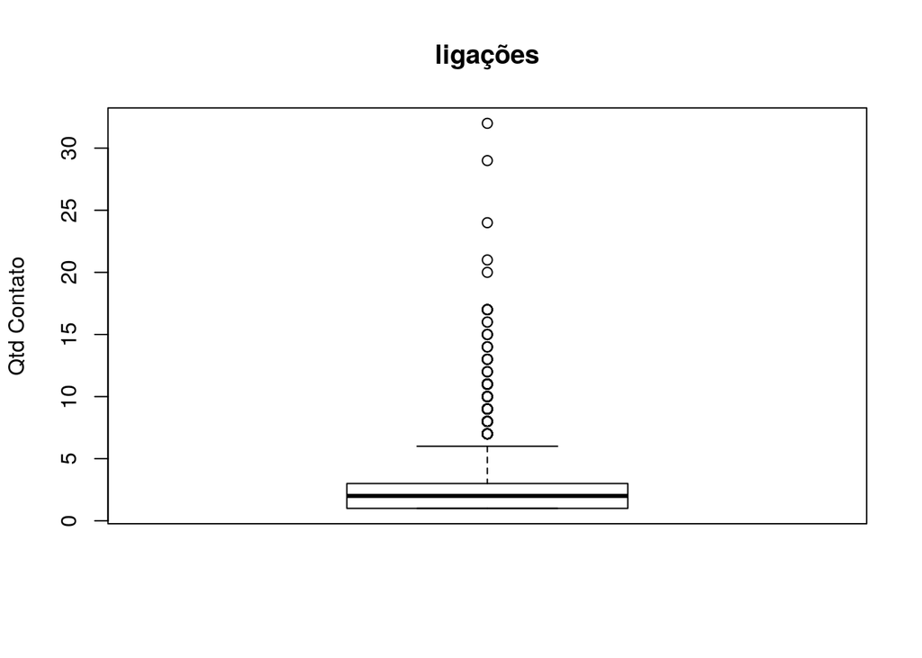

```r
dados_true <- dados %>% filter(y == 'yes')

boxplot(dados_true$campaign, data=dados_true$campaign, main="ligações", ylab="Qtd Contato")
```

Observando a distribuição dos dados em relação a quantidade de ligações, notamos que existem muitos outliers. Além disso, notamos que com cerca de 3 ligações já pegamos 75% de todos os casos de sucesso.

Olhando mais no detalhe os dados temos:

```r
summary(dados_true$campaign)
```

```
##    Min. 1st Qu.  Median    Mean 3rd Qu.    Max.
##   1.000   1.000   2.000   2.141   3.000  32.000
```

##### Insight 7

A base toda possui 17 variáveis, será que todas essas informações são úteis e podem ajudar a gente a decidir quando o banco deve oferencer um emprestimo?

Ao rodar uma regressão logística temos:

```r
treino_labels = dados[, 17] ## Classes das instâncias de treino
treino = dados[-c(17)] ## Exclui variável alvo

glmFit <- train(treino, treino_labels, method= "glm")

summary(glmFit)
```

```
##
## Call:
## NULL
##
## Deviance Residuals:
##     Min       1Q   Median       3Q      Max
## -5.7286  -0.3744  -0.2530  -0.1502   3.4288
##
## Coefficients:
##                      Estimate Std. Error z value Pr(>|z|)
## (Intercept)        -2.536e+00  1.837e-01 -13.803  < 2e-16 ***
## age                 1.127e-04  2.205e-03   0.051 0.959233
## jobblue-collar     -3.099e-01  7.267e-02  -4.264 2.01e-05 ***
## jobentrepreneur    -3.571e-01  1.256e-01  -2.844 0.004455 **
## jobhousemaid       -5.040e-01  1.365e-01  -3.693 0.000221 ***
## jobmanagement      -1.653e-01  7.329e-02  -2.255 0.024130 *
## jobretired          2.524e-01  9.722e-02   2.596 0.009436 **
## jobself-employed   -2.983e-01  1.120e-01  -2.664 0.007726 **
## jobservices        -2.238e-01  8.406e-02  -2.662 0.007763 **
## jobstudent          3.821e-01  1.090e-01   3.505 0.000457 ***
## jobtechnician      -1.760e-01  6.893e-02  -2.554 0.010664 *
## jobunemployed      -1.767e-01  1.116e-01  -1.583 0.113456
## jobunknown         -3.133e-01  2.335e-01  -1.342 0.179656
## maritalmarried     -1.795e-01  5.891e-02  -3.046 0.002318 **
## maritalsingle       9.250e-02  6.726e-02   1.375 0.169066
## educationsecondary  1.835e-01  6.479e-02   2.833 0.004618 **
## educationtertiary   3.789e-01  7.532e-02   5.031 4.88e-07 ***
## educationunknown    2.505e-01  1.039e-01   2.411 0.015915 *
## defaultyes         -1.668e-02  1.628e-01  -0.102 0.918407
## balance             1.283e-05  5.148e-06   2.493 0.012651 *
## housingyes         -6.754e-01  4.387e-02 -15.395  < 2e-16 ***
## loanyes            -4.254e-01  5.999e-02  -7.091 1.33e-12 ***
## contacttelephone   -1.634e-01  7.519e-02  -2.173 0.029784 *
## contactunknown     -1.623e+00  7.317e-02 -22.184  < 2e-16 ***
## day                 9.969e-03  2.497e-03   3.993 6.53e-05 ***
## monthaug           -6.939e-01  7.847e-02  -8.842  < 2e-16 ***
## monthdec            6.911e-01  1.767e-01   3.912 9.17e-05 ***
## monthfeb           -1.473e-01  8.941e-02  -1.648 0.099427 .
## monthjan           -1.262e+00  1.217e-01 -10.367  < 2e-16 ***
## monthjul           -8.308e-01  7.740e-02 -10.733  < 2e-16 ***
```

[output cut: 8 more lines]

```
## pdays              -1.027e-04  3.061e-04  -0.335 0.737268
## previous            1.015e-02  6.503e-03   1.561 0.118476
## poutcomeother       2.035e-01  8.986e-02   2.265 0.023543 *
## poutcomesuccess     2.291e+00  8.235e-02  27.821  < 2e-16 ***
## poutcomeunknown    -9.179e-02  9.347e-02  -0.982 0.326093
## ---
## Signif. codes:  0 '***' 0.001 '**' 0.01 '*' 0.05 '.' 0.1 ' ' 1
##
## (Dispersion parameter for binomial family taken to be 1)
##
##     Null deviance: 32631  on 45210  degrees of freedom
## Residual deviance: 21562  on 45168  degrees of freedom
## AIC: 21648
##
## Number of Fisher Scoring iterations: 6
```

As informações de campanha anterior tem relevância no resultado da campanha atual, como podemos notar no resultado da regressão. Por outro lado, as informações pdays, previous, defaultyes e age não tem relavância para o sucesso do emprestimo ou não

##### Insight 8

Olhando agora para empréstimo imobiliário, podemos notar que essas pessoas tem algumas características proeminentes

```r
dados_housing <- dados %>% filter(housing == 'yes')

summary(dados_housing)
```

```
##       age                  job           marital          education
##  Min.   :20.00   blue-collar :7048   divorced: 2907   primary  : 3894
##  1st Qu.:32.00   management  :4678   married :15321   secondary:14038
##  Median :38.00   technician  :4115   single  : 6902   tertiary : 6378
##  Mean   :39.18   admin.      :3182                    unknown  :  820
##  3rd Qu.:45.00   services    :2766
##  Max.   :78.00   entrepreneur: 869
##                  (Other)     :2472
##  default        balance      housing      loan            contact
##  no :24695   Min.   :-4057   no :    0   no :20763   cellular :14603
##  yes:  435   1st Qu.:   62   yes:25130   yes: 4367   telephone: 1170
##              Median :  412                           unknown  : 9357
##              Mean   : 1175
##              3rd Qu.: 1258
##              Max.   :58544
##
##       day           month          duration         campaign
##  Min.   : 1.0   may    :12076   Min.   :   0.0   Min.   : 1.000
##  1st Qu.: 8.0   jul    : 3338   1st Qu.: 103.0   1st Qu.: 1.000
##  Median :15.0   jun    : 2227   Median : 182.0   Median : 2.000
##  Mean   :15.6   nov    : 2214   Mean   : 259.3   Mean   : 2.698
##  3rd Qu.:21.0   apr    : 2069   3rd Qu.: 318.0   3rd Qu.: 3.000
##  Max.   :31.0   feb    : 1132   Max.   :4918.0   Max.   :63.000
##                 (Other): 2074
##      pdays           previous           poutcome       y
##  Min.   : -1.00   Min.   :  0.0000   failure: 3470   no :23195
##  1st Qu.: -1.00   1st Qu.:  0.0000   other  : 1199   yes: 1935
##  Median : -1.00   Median :  0.0000   success:  471
##  Mean   : 51.31   Mean   :  0.6567   unknown:19990
##  3rd Qu.: -1.00   3rd Qu.:  0.0000
##  Max.   :854.00   Max.   :275.0000
##
```

Na sua grande maioria elas tem até 45 anos, trabalham como blue-collar, são casadas e possui o secondary

##### Insight 9

Algumas pessoas já tem um crédito pré aprovado junto ao banco. Será que essas pessoas tem muito dinheiro no banco e por essa razão já possui esse emprestimo?

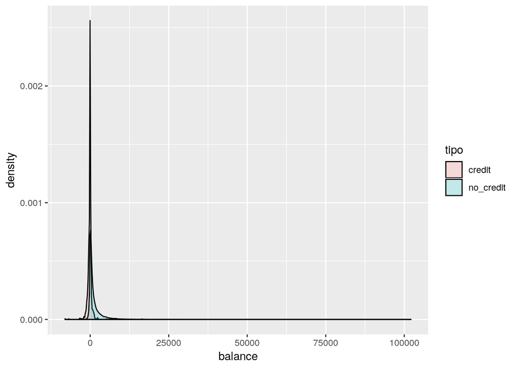

```r
dados_credit <- dados %>% filter(default == 'yes')
dados_no_credit <- dados %>% filter(default == 'no')

credit <- data.frame(balance = dados_credit$balance)
no_credit <- data.frame(balance =  dados_no_credit$balance)

credit$tipo <- 'credit'
no_credit$tipo <- 'no_credit'

hist_credit <- rbind(credit, no_credit)

ggplot(hist_credit, aes(balance, fill = tipo)) + geom_density(alpha = 0.2)
```